# Estimating species richness from an aggregation of inventory plots

Eric Marcon

30 October 2022

# 1 Rationale

The Chao2 estimator (Chao 1987) can be used to estimate the richness of a community from occurrence data in sampling plots.

It has been applied by Cazzolla Gatti et al. (2022) to abundance data of small sample plots aggregated into occurrence data on a grid. The question addressed here is the relationship between the aggregation level and the resulting estimation.

The estimation actually does not depend on the aggregation level.

# 2 Data

A large, spatialized community is simulated by package *SpatDiv*. The community is log-normal. Spatially, tree species are clustered according to a Thomas process.

Parameters are:

- the size of the square window of the simulation, including the name of units,
- the number of trees per unit area,
- the number of species,
- the parameters of aggregation: the standard deviation of the displacements of points around the cluster centers (`thomas_scale`) and the average number of trees per cluster (`thomas_mu`).

The simulation may take time and memory over 100,000 trees.

```r
library("SpatDiv")
window_size <- 20000
unit_name <- c("meter", "meters")
trees_n_per_area <- 500/10000
species_n <- 500
thomas_scale <- window_size/10
thomas_mu <- 100
```

The community is simulated:

```r
library("spatstat")
rSpCommunity(n = 1, size = window_size^2 * trees_n_per_area,
    S = species_n, Spatial = "Thomas", scale = thomas_scale,
    mu = thomas_mu, win = square(r = window_size, unitname = unit_name)) ->
    spCommunity
# Number of trees
spCommunity$n
```

```
## [1] 20024041
```

Square, random inventory plots are simulated in the community.

Their parameters are: - their size, - their number.

```r
# Plot side length
plots_side <- 30
# Number of plots
plots_n <- 50
```

Random coordinates are drawn:

```r
# Draw random plots
X_0 <- runif(plots_n, max = window_size)
Y_0 <- runif(plots_n, max = window_size)
# Push the plots into the window
X_min <- pmin(X_0, window_size - plots_side)
X_max <- pmin(X_0 + plots_side, window_size)
Y_min <- pmin(Y_0, window_size - plots_side)
Y_max <- pmin(Y_0 + plots_side, window_size)
# List of windows
plots_windows <- solapply(seq_along(X_0), function(i) owin(xrange = c(X_min[i],
    X_max[i]), yrange = c(Y_min[i], Y_max[i]), unitname = unit_name))
# Coordinates of the plots in a dataframe
plots_coords <- data.frame(Plot = seq_len(plots_n),
    X = X_min, Y = Y_min)
```

The plots are mapped:

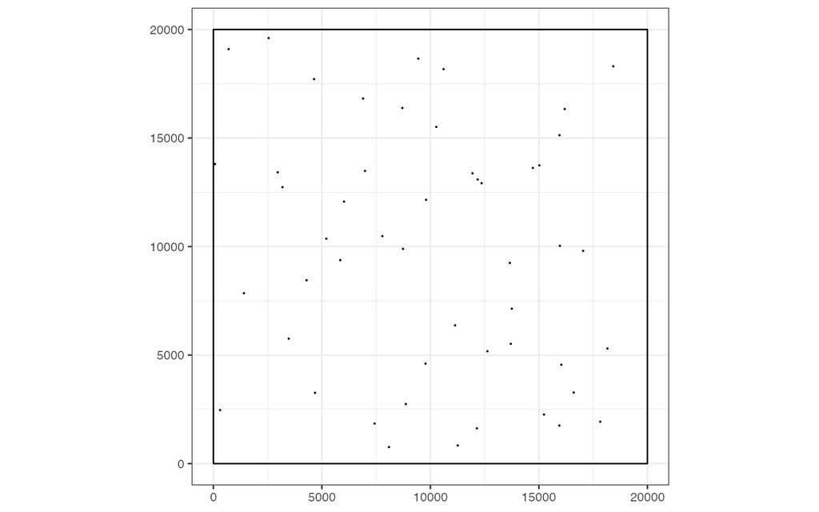

```r
# spatstat
# plot(intersect.owin(spCommunity$window,
# union.owin(plots_windows)))
# ggplot
window_all <- data.frame(xmin = c(spCommunity$window$xrange[1],
    X_min), xmax = c(spCommunity$window$xrange[2],
    X_max), ymin = c(spCommunity$window$yrange[1],
    Y_min), ymax = c(spCommunity$window$yrange[2],
    Y_max))
library("ggplot2")
gg_plots <- ggplot() + geom_rect(data = window_all,
    mapping = aes(xmin = xmin, xmax = xmax, ymin = ymin,
        ymax = ymax), color = "black", fill = "transparent") +
    coord_fixed()
print(gg_plots)
```

The sampling intensity is 0.0112% of the total area.

Any plot can be mapped with its content. The first one is:

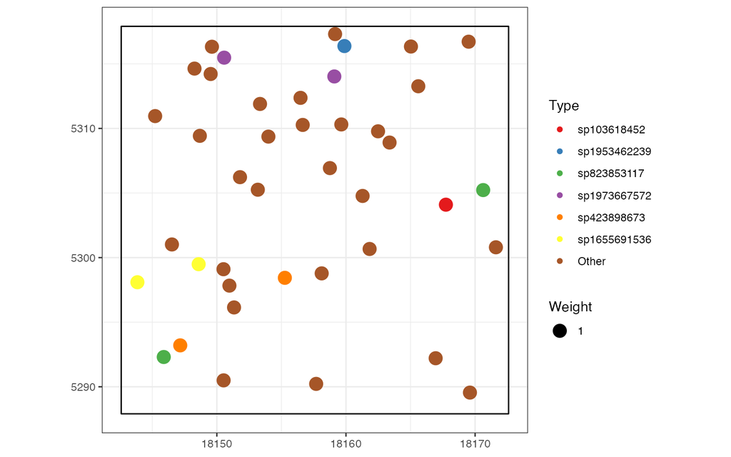

```r
plot_to_draw <- plots_windows[[1]]
library("dbmss")
autoplot(spCommunity[plot_to_draw])
```

# 3 Inventory

The inventory of a plot is made by the `plot_trees()` function which return a boolean vector for all the trees of the community. Its value is `TRUE` when a tree is in the plot.

```r
plot_trees <- function(spCommunity, plots_side, x_0,
    y_0) {
    # Trees in the plot
    is_in <- (spCommunity$x >= x_0) & (spCommunity$x <=
        x_0 + plots_side) & (spCommunity$y >= y_0) &
        (spCommunity$y <= y_0 + plots_side)
    return(is_in)
}
```

The inventory is simulated: the trees inside each plot are listed and a abundance by plot dataframe is produced.

```r
# Initialize a dataframe with factors
plots_inventory <- data.frame()
# Inventory
for (i in seq_len(plots_n)) {
    plot_inventory <- data.frame(Plot = i, Tree = spCommunity$marks$PointType[plot_trees(spCommunity,
        plots_side, X_min[i], Y_min[i])])
    plots_inventory <- rbind(plots_inventory, plot_inventory)
}
# Transform the inventory into an abundance table
library("tidyverse")
plots_inventory %>%
    group_by(Plot, Tree) %>%
    summarise(Abundance = n()) %>%
    pivot_wider(names_from = Tree, values_from = Abundance,
        values_fill = 0) -> plots_abundances
```

# 4 Aggregation

```r
# Group plots in a grid
group_plots <- function(plots, grid_x, grid_y) {
    grid_xy <- matrix(0, nrow = nrow(plots), ncol = 2)
    for (row in seq_len(nrow(plots))) {
        grid_xy[row, 1] <- grid_x[max(which(plots$X[row] >
            grid_x))]
        grid_xy[row, 2] <- grid_y[max(which(plots$Y[row] >
            grid_y))]
    }
    colnames(grid_xy) <- c("x_grid", "y_grid")
    return(grid_xy)
}
```

```r
abundance_gridded <- function(abundances, plots, grid_size,
    x_min = 0, x_max = 1, y_min = 0, y_max = 1) {
    grid_x <- seq(x_min, x_max, by = grid_size)
    grid_y <- seq(y_min, y_max, by = grid_size)
    plots_gridded <- cbind(plots["Plot"], group_plots(plots,
        grid_x, grid_y))
    abundances %>%
        inner_join(plots_gridded) %>%
        select(-Plot) %>%
        group_by(x_grid, y_grid) %>%
        summarise_all(sum) -> abundances_aggregated
    return(abundances_aggregated)
}
```

The `richness_gridded()` function returns the estimation of richness by the Chao2 estimator after aggregating the plots of each cell of the grid.

```r
richness_gridded <- function(abundances, plots, grid_size,
    x_min = 0, x_max = 1, y_min = 0, y_max = 1) {
    abundances_aggregated <- abundance_gridded(abundances,
        plots, grid_size, x_min, x_max, y_min, y_max)
    occurences <- apply(abundances_aggregated[, -(1:3)],
        2, function(x) sum(x > 0))
    n <- nrow(abundances_aggregated)
    s_obs <- sum(occurences > 0)
    s_1 <- sum(occurences == 1)
    s_2 <- sum(occurences == 2)
    s_chao2 <- ifelse(s_2 > 0, s_obs + (n - 1) * s_1^2/2/n/s_2,
        s_obs + (n - 1) * s_1 * (s_1 - 1)/2/n)
    return(s_chao2)
}
```

The estimation of the number of species with a 4-cell grid is:

```r
# Example
richness_gridded(plots_abundances, plots_coords, grid_size = window_size/2,
    x_max = window_size, y_max = window_size)
```

```
## [1] 449.7821
```

The sensitivity to the grid size is evaluated by dividing it by 2 several times (from 1/2 to 1/32 of the community size).

```r
sapply(1:5, function(n) richness_gridded(plots_abundances,
    plots_coords, grid_size = window_size/2^n, x_max = window_size,
    y_max = window_size))
```

```
## [1] 449.7821 440.2547 443.8865 444.3175 444.3793
```

The estimation is very stable.

A grid size equal to 1/8th of the window (64 cells) is shown here:

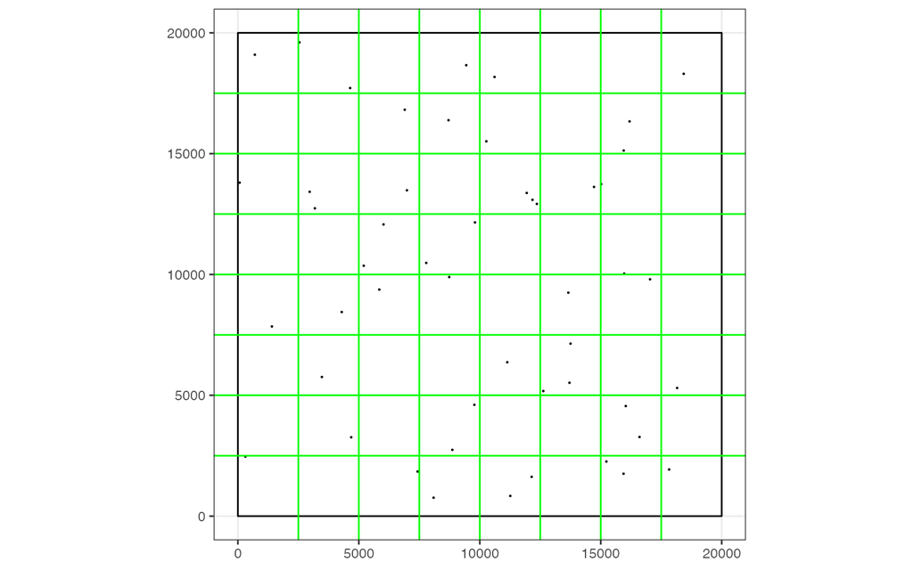

```r
grid_interval <- window_size/2^3
grid_seq <- seq(grid_interval, window_size * 0.9999,
    by = grid_interval)
gg_plots + geom_hline(yintercept = grid_seq, col = "green") +
    geom_vline(xintercept = grid_seq, col = "green")
```

The estimation of richness could be made directly from the abundance data:

```r
Richness(colSums(plots_abundances[, -1]))
```

```
## Jackknife 1
##         485
```

# 5 Turing’s relation

## 5.1 Estimating the number of singletons

Turing’s relation is used to derived the number of singletons $s_1$ from $s_2$, $s_3$ and $s_4$ after Chiu and Chao (2016).

The `turing()` function estimates that number of singletons to compare it to the observed one in simulated inventories.

```r
turing <- function(distribution, Cazzola2022 = FALSE,
    verbose = TRUE) {
    n <- sum(distribution)
    s_1 <- sum(distribution == 1)
    if (verbose)
        cat("Actual number of singletons:", s_1, "\n")
    s_2 <- sum(distribution == 2)
    s_3 <- sum(distribution == 3)
    s_4 <- sum(distribution == 4)
    # Chiu at al. 2016 : s_1_hat <- (4 *s_2^2 /3
    # /s_3 - 2 * s_2 * s_3 /4 /s_4) Keep n in
    # Chiu at al. 2016
    s_1_hat <- 4 * (n - 2) * s_2^2/3/(n - 1)/s_3 -
        (n - 3) * s_2 * s_3/2/(n - 1)/s_4
    # Cazzola 2022
    if (Cazzola2022)
        s_1_hat <- (n - 1)/n * 2 * s_2 * (5 * s_2/6/s_3 -
            s_3/4/s_4)
    if (verbose)
        cat("Expected number of singletons:", s_1_hat,
            "\n")
    return(invisible(s_1_hat))
}
```

The formula in Cazzolla Gatti et al. (2022) differs from that of Chiu and Chao (2016). It is
$$\hat{s_1}=\frac{(n-1)}{n}\frac{2s_2^2}{3s_3} + \frac{(n-1)}{n} 2s_2 \left(\frac{s_2}{2s_3}-\frac{s_3}{4s_4}\right)$$
but the original equation is (eq. 5 of Chiu and Chao 2016 rederived without assuming $n$ is large):
$$\hat{s_1}=\frac{(n-2)}{n-1}\frac{2s_2^2}{3s_3} + \frac{(n-2)}{n-1} 2s_2 \left(\frac{s_2}{3s_3}-\frac{s_3}{4s_4}\right).$$
The denominator of the first term of the second-to-last fraction is $3s_3$, not $2s_3$.

The estimation differs quite much, e.g. in a log-normal community:

```r
# Single community
community_lnorm <- rCommunity(1, size = 1000)
# Original equation
turing(community_lnorm, Cazzola2022 = FALSE)
```

```
## Actual number of singletons: 68
## Expected number of singletons: 50.52703
```

```r
# 3 instead of 2
turing(community_lnorm, Cazzola2022 = TRUE)
```

```
## Actual number of singletons: 68
## Expected number of singletons: 70.35991
```

Applied to the simulated community the estimation is sometimes correct but sometimes not, depending on the simulation:

```r
# Abundances
turing(colSums(plots_abundances[, -1]))
```

```
## Actual number of singletons: 74
## Expected number of singletons: 138.4418
```

```r
# Aggregated data, 64 cells
abundances_aggregated <- abundance_gridded(plots_abundances,
    plots_coords, grid_size = window_size/2^3, x_max = window_size,
    y_max = window_size)
occurences <- apply(abundances_aggregated[, -(1:3)],
    2, function(x) sum(x > 0))
turing(occurences)
```

```
## Actual number of singletons: 78
## Expected number of singletons: 150.5692
```

## 5.2 Empirical validation

A simulation of log-normal communities shows poor empirical relations, both on simulated, small communities or on samples of a large community.

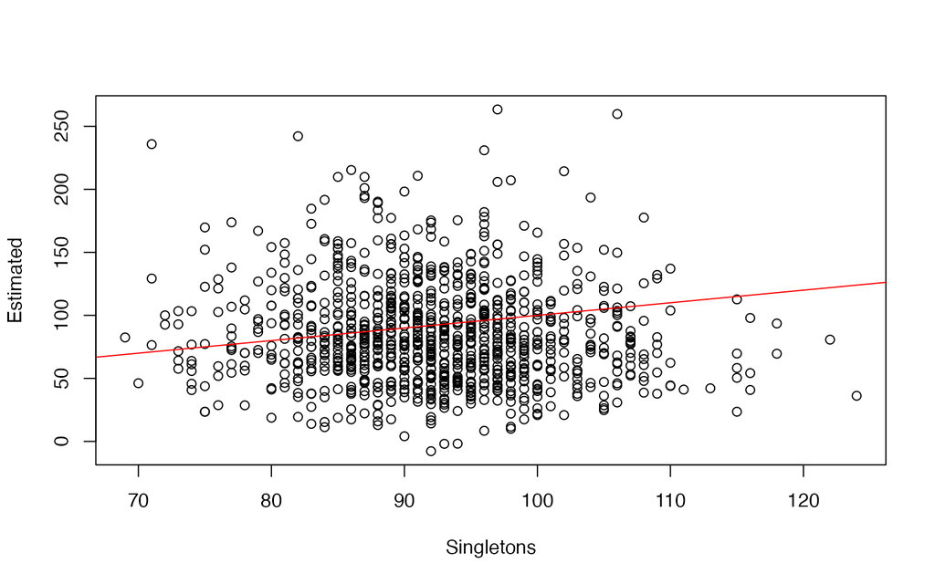

```r
# Small communities
simln <- rCommunity(1000, size = plots_side^2 * plots_n *
    trees_n_per_area, Distribution = "lnorm", S = species_n)
Singletons <- apply(simln$Nsi, 2, function(distribution) sum(distribution ==
    1))
Estimated <- apply(simln$Nsi, 2, turing, verbose = FALSE)
plot(x = Singletons, y = Estimated)
abline(a = 0, b = 1, col = "red")
```

```r
summary(lm(Estimated ~ Singletons))
```

```
##
## Call:
## lm(formula = Estimated ~ Singletons)
##
## Residuals:
##     Min      1Q  Median      3Q     Max
## -93.111 -27.373  -5.918  22.105 179.857
##
## Coefficients:
##             Estimate Std. Error t value Pr(>|t|)
## (Intercept) 118.1361    14.1268   8.363   <2e-16
## Singletons   -0.3566     0.1524  -2.340   0.0195
##
## (Intercept) ***
## Singletons  *
## ---
## Signif. codes:
## 0 '***' 0.001 '**' 0.01 '*' 0.05 '.' 0.1 ' ' 1
##
## Residual standard error: 39.86 on 998 degrees of freedom
## Multiple R-squared:  0.005455,   Adjusted R-squared:  0.004459
## F-statistic: 5.474 on 1 and 998 DF,  p-value: 0.0195
```

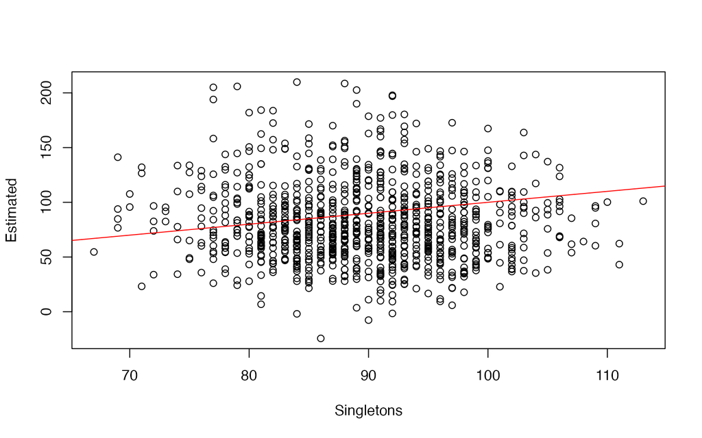

```r
# Large community
simln <- rCommunity(1, size = 1e+06, Distribution = "lnorm",
    S = species_n)
# Samples
samples <- rmultinom(1000, size = plots_side^2 * plots_n *
    trees_n_per_area, prob = as.ProbaVector(simln))
Singletons <- apply(samples, 2, function(distribution) sum(distribution ==
    1))
Estimated <- apply(samples, 2, turing, verbose = FALSE)
plot(Estimated ~ Singletons)
abline(a = 0, b = 1, col = "red")
```

```r
summary(lm(Estimated ~ Singletons))
```

```
##
## Call:
## lm(formula = Estimated ~ Singletons)
##
## Residuals:
##      Min       1Q   Median       3Q      Max
## -106.816  -24.526   -5.147   20.423  126.972
##
## Coefficients:
##             Estimate Std. Error t value Pr(>|t|)
## (Intercept) 100.1986    13.2622   7.555 9.44e-14
## Singletons   -0.2062     0.1477  -1.396    0.163
##
## (Intercept) ***
## Singletons
## ---
## Signif. codes:
## 0 '***' 0.001 '**' 0.01 '*' 0.05 '.' 0.1 ' ' 1
##
## Residual standard error: 35.74 on 998 degrees of freedom
## Multiple R-squared:  0.001948,   Adjusted R-squared:  0.0009484
## F-statistic: 1.948 on 1 and 998 DF,  p-value: 0.1631
```

The estimation of $\alpha_r$ with Turing’s formula is not better.

```r
# Turing's formula.
alpha_r <- function(distribution, sample, r) {
    f_r <- sum(sample == r)
    f_rplus1 <- sum(sample == r + 1)
    n <- sum(sample)
    alpha_r_sim <- c(Actual = mean(as.ProbaVector(distribution)[sample ==
        r]), Turing = (r + 1) * f_rplus1/((n - r) *
        f_r + (r + 1) * f_rplus1))
    return(alpha_r_sim)
    # Return a vector: actual and estimated
    # alpha_r
}
```

A large community is simulated and many samples in it.

```r
# Large community
simln <- rCommunity(1, size = 1e+06, Distribution = "lnorm",
    S = species_n)
# Many samples
samples <- rmultinom(1000, size = 1000, simln)
```

The actual and estimated values of $\alpha_r$ are calculated:

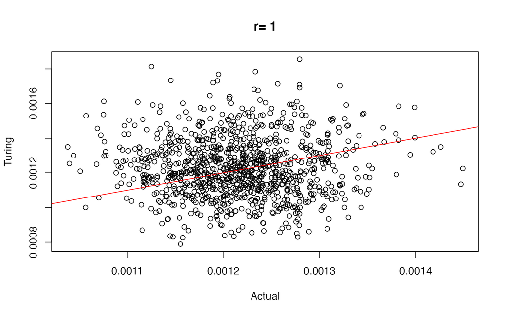

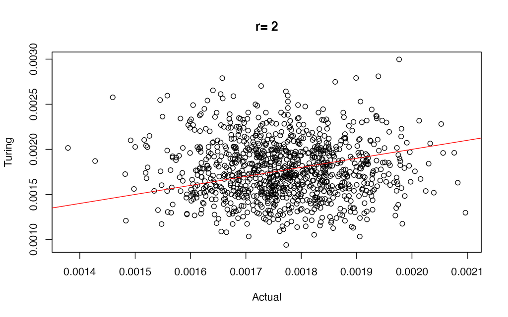

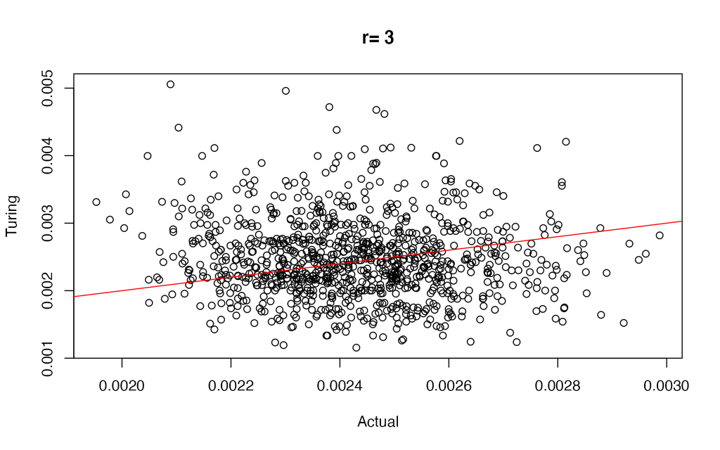

```r
# Plot actual vs estimated alpha_r
compare_alpha_r <- function(distribution, sample, r) {
    alpha_rsim <- t(apply(samples, 2, function(sample) alpha_r(distribution,
        sample, r)))
    plot(alpha_rsim, main = paste("r=", r))
    abline(a = 0, b = 1, col = "red")
}
sapply(1:3, function(r) compare_alpha_r(simln, sample,
    r))
```

## 5.3 Cause for the poor predictions

This is not due to the approximation in the derivation of the improved Turing formula (Chiu et al. 2014, eq. 7a):

```r
# Evaluate Chiu at al. 2014 approximation
odd_approximation <- function(distribution, sample,
    r) {
    distribution_p <- as.ProbaVector(distribution)
    p_r <- distribution_p[sample == r]
    odd_r_sum <- sum(p_r/(1 - p_r))
    odd_r_mean <- mean(p_r)/mean(1 - p_r) * sum(sample ==
        r)
    return(c(odd_r_sum, odd_r_mean))
}
# Large community
simln <- rCommunity(1, size = 1e+06, Distribution = "lnorm",
    S = species_n)
sample <- rmultinom(1, size = 1000, simln)
# Approximation
odd_approximation(simln, sample, 1)
```

```
## [1] 0.1712749 0.1711658
```

```r
odd_approximation(simln, sample, 2)
```

```
## [1] 0.1325325 0.1324687
```

```r
odd_approximation(simln, sample, 3)
```

```
## [1] 0.1359644 0.1358157
```

```r
odd_approximation(simln, sample, 4)
```

```
## [1] 0.1093725 0.1092968
```

## 5.4 Appropriate application

Turing’s relation does not allow to predict the observed number of singletons of a specific sample. It is made to estimate the expected number of singletons. The following test compares the mean estimation to the mean number of observed singletons over 1000 simulations of samples of increasing size in a large community.

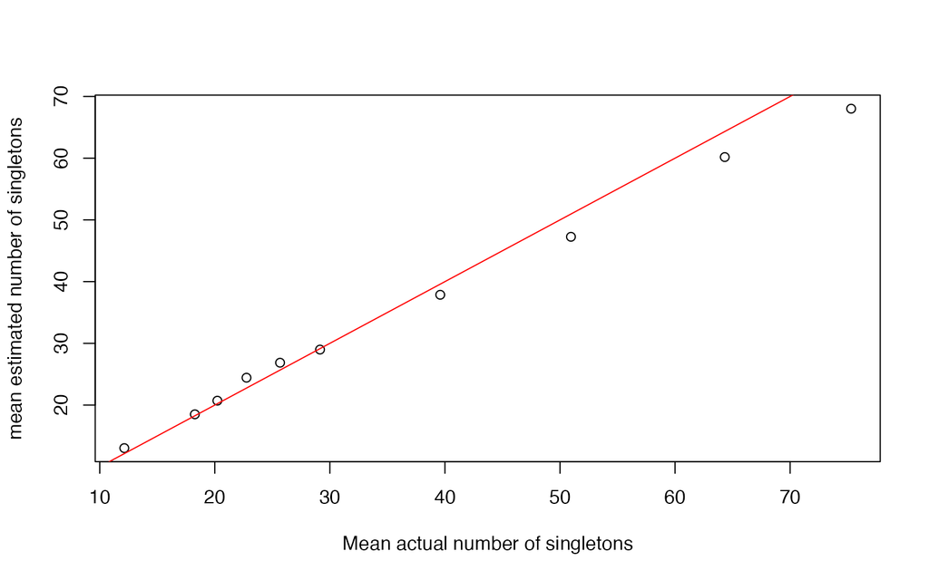

```r
estimate_f1 <- function(sample_size) {
    # Large community
    simln <- rCommunity(1, size = 1e+06, Distribution = "lnorm",
        S = 300)
    # Many samples
    samples <- rmultinom(1000, size = sample_size,
        simln)
    # Actual and estimated number of singletons
    Singletons <- mean(apply(samples, 2, function(distribution) sum(distribution ==
        1)))
    Estimated <- mean(apply(samples, 2, turing, verbose = FALSE))
    return(c(Singletons, Estimated))
}
f1_estimation <- sapply(seq(500, 5000, by = 500), estimate_f1)
plot(t(f1_estimation), xlab = "Mean actual number of singletons",
    ylab = "mean estimated number of singletons")
abline(a = 0, b = 1, col = "red")
```

The larger the samples (from 500 to 5000 individuals in a 300-species community), the less singletons. The estimation is quite good on average.

## 5.5 Application to the data

The `richness_gridded()` function is modified to use the number of singletons derived by Turing’s relation rather than the observed data. The argument `turing_f1` is added for that purpose.

```r
richness_gridded <- function(abundances, plots, grid_size,
    x_min = 0, x_max = 1, y_min = 0, y_max = 1, turing_f1 = FALSE) {
    abundances_aggregated <- abundance_gridded(abundances,
        plots, grid_size, x_min, x_max, y_min, y_max)
    occurences <- apply(abundances_aggregated[, -(1:3)],
        2, function(x) sum(x > 0))
    n <- nrow(abundances_aggregated)
    s_obs <- sum(occurences > 0)
    s_2 <- sum(occurences == 2)
    s_3 <- sum(occurences == 3)
    s_4 <- sum(occurences == 4)
    if (turing_f1) {
        s_1 <- 4 * (n - 2) * s_2^2/3/(n - 1)/s_3 -
            (n - 3) * s_2 * s_3/2/(n - 1)/s_4
    } else {
        s_1 <- sum(occurences == 1)
    }
    s_chao2 <- ifelse(s_2 > 0, s_obs + (n - 1) * s_1^2/2/n/s_2,
        s_obs + (n - 1) * s_1 * (s_1 - 1)/2/n)
    return(s_chao2)
}
```

The estimation of the number of species with a 4-cell grid is:

```r
# Example
richness_gridded(plots_abundances, plots_coords, grid_size = window_size/2,
    x_max = window_size, y_max = window_size, turing_f1 = TRUE)
```

```
## [1] 458.9968
```

The sensitivity to the grid size is evaluated by dividing it by 2 several times (from 1/2 to 1/32 of the community size).

```r
sapply(1:5, function(n) richness_gridded(plots_abundances,
    plots_coords, grid_size = window_size/2^n, x_max = window_size,
    y_max = window_size, turing_f1 = TRUE))
```

```
## [1] 458.9968 531.0000 529.4330 513.2747 530.0871
```

These values are to be compared with those obtained above.

# References

Cazzolla Gatti, Roberto, Peter B. Reich, Javier G. P. Gamarra, Tom Crowther, Cang Hui, Albert Morera, Jean-Francois Bastin, et al. 2022. “The Number of Tree Species on Earth.” *Proceedings of the National Academy of Sciences* 119 (6): e2115329119. https://doi.org/10.1073/pnas.2115329119.

Chao, Anne. 1987. “Estimating the Population Size for Capture-Recapture Data with Unequal Catchability.” *Biometrics* 43 (4): 783–91. https://doi.org/10.2307/2531532.

Chiu, Chun-Huo, and Anne Chao. 2016. “Estimating and Comparing Microbial Diversity in the Presence of Sequencing Errors.” *PeerJ* 4: e1634. https://doi.org/10.7717/peerj.1634.

Chiu, Chun-Huo, Yi-Ting Wang, Bruno A. Walther, and Anne Chao. 2014. “An Improved Nonparametric Lower Bound of Species Richness via a Modified Good-Turing Frequency Formula.” *Biometrics* 70 (3): 671–82. https://doi.org/10.1111/biom.12200.